# Standard pre-processing workflow

Naomi Croft

21/11/2023

The steps below encompass the standard pre-processing workflow for scRNA-seq data in Seurat. These represent the selection and filtration of cells based on QC metrics, data normalization and scaling, and the detection of highly variable features. The script then breifly shows how to cluster cells, identify differentially expressed genes and remove noise.

## Loading modules

```r
library(Seurat, quietly = TRUE)
```

```r
library(cowplot, quietly = TRUE)
library(ggplot2, quietly = TRUE)
library(Matrix, quietly = TRUE)
library(magrittr, quietly = TRUE)
library(plyr, quietly = TRUE)
library(dplyr, quietly = TRUE)
library(tidyverse, quietly = TRUE)
library(umap, quietly = TRUE)
```

```r
merge_seuratfish <- readRDS("merge_seuratfish.rds")
#Treatment column represents the sampling timepoint during a vaccination and immune challenge experiment. i.e. 'PreImm' represents fish samples prior to immunisation.
#orig.ident represents fish sample ID
head(merge_seuratfish@meta.data)
```

```
##                 orig.ident nCount_RNA nFeature_RNA treatment percent.mt
## CATCCATCAAGT_01         01       6283         2377    PreImm  2.0213274
## GCGCATCCGTGC_01         01       7585         2874    PreImm  2.3335531
## GAGTTATTCTCC_01         01       3770          408    PreImm  0.4244032
## CCTATCCTCGGT_01         01       3533         1564    PreImm  1.7548825
## GATGAGGCAAAG_01         01       3936         1512    PreImm  4.0142276
## TACTCGTGACTG_01         01       3279         1524    PreImm  2.4702653
```

## Quality control

The percentage of reads that map to the mitochondrial genome is a common quality control metric. These are not noted on the non-model Atlantic cod genome as in human/mouse genomes. So I have used ‘grep’ function on the annotated genome to create a list of existing genes (mithochondrial_gene_names.txt) which have the word “mitochond” in their protein name

```r
mt.list<-read.table("mithochondrial_gene_names.txt", header=F) # the list of mithochondrial genes from GadMor3
mt.list<-unlist(mt.list$V1)
mt.list<-mt.list[mt.list %in% rownames(merge_seuratfish)] # Find those that are in the seurat object
all(mt.list %in% rownames(merge_seuratfish)) # Just to make sure that the previous line worked
```

```
## [1] TRUE
```

```r
#mt.list # See which genes are represented in the data

merge_seuratfish[["percent.mt"]] <- PercentageFeatureSet(merge_seuratfish, features = mt.list, assay="RNA")
```

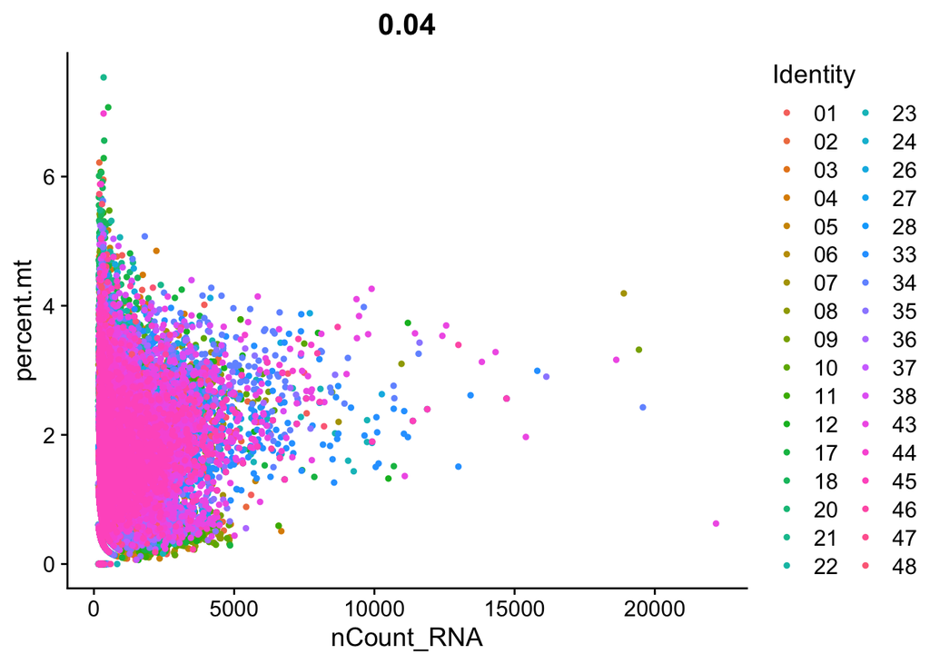

```r
#nCount_RNA represents the number of transcripts per gene per cell
#nFeature_RNA represents the number of genes per cell
FeatureScatter(merge_seuratfish, feature1 = "nCount_RNA", feature2 = "percent.mt")
```

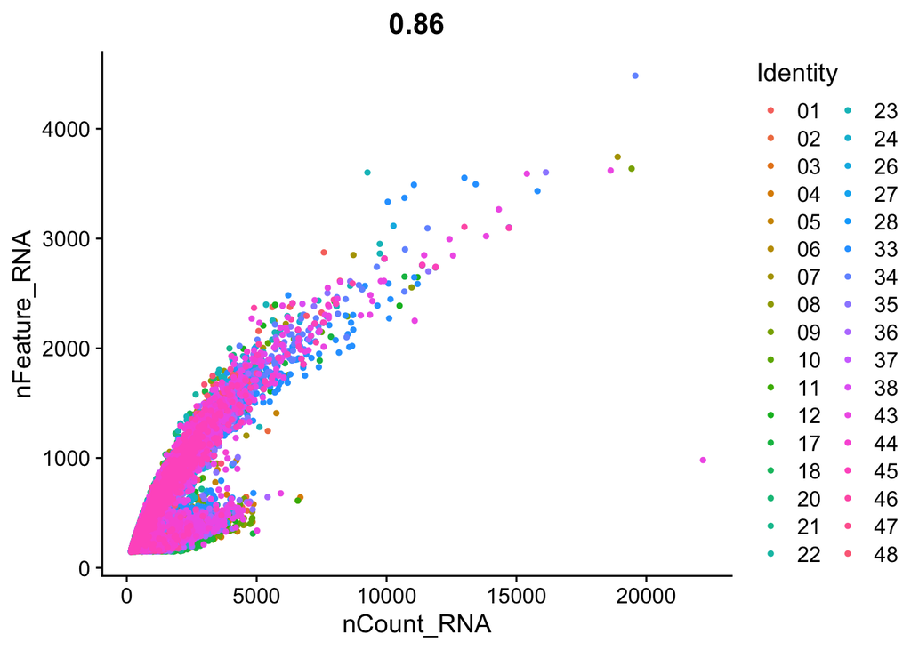

```r
FeatureScatter(merge_seuratfish, feature1 = "nCount_RNA", feature2 = "nFeature_RNA")
```